# Problem Set 09

Your Name Here

Last compiled: August 20, 2023 at 10:27:18 AM

# 1 Background

First load the necessary packages:

```r
library(tidyverse)
library(infer)
```

For this Problem Set, you will work with some grade-point-average (GPA) data for college freshman. The following will read in the data:

```r
if(!dir.exists("./Data")){
  dir.create("./Data")
  }
url <- "https://rudeboybert.github.io/SDS220/static/PS/sat_gpa.csv"
if(!file.exists("./Data/sat_gpa.csv")){
  download.file(url, destfile = "./Data/sat_gpa.csv")
  }
sat_gpa <- read_csv("./Data/sat_gpa.csv")
DT::datatable(sat_gpa, rownames = FALSE)
```

| ...1 | sex | sat_verbal | sat_math | sat_total | gpa_hs | gpa_fy |
| --- | --- | --- | --- | --- | --- | --- |
| 1 | Male | 65 | 62 | 127 | high | 3.18 |
| 2 | Female | 58 | 64 | 122 | high | 3.33 |
| 3 | Female | 56 | 60 | 116 | high | 3.25 |
| 4 | Male | 42 | 53 | 95 | high | 2.42 |
| 5 | Male | 55 | 52 | 107 | high | 2.63 |
| 6 | Female | 55 | 56 | 111 | high | 2.91 |
| 7 | Male | 57 | 65 | 122 | low | 2.83 |
| 8 | Male | 53 | 62 | 115 | high | 2.51 |
| 9 | Female | 67 | 77 | 144 | high | 3.82 |
| 10 | Male | 41 | 44 | 85 | low | 2.54 |

[output cut: 990 more lines]

Figure 1.1: SAT versus GPA data

Be sure to take a look at the data in Figure 1.1. Each row or case in this data frame is a student. The data includes the (binary) gender of each student; the math, verbal and total SAT scores for each student; the GPA of each student in high school (categorized as “low” or “high”); and the GPA of each student their first year of college on a numeric scale.

We will use hypothesis testing to answer the following questions:

- Is there a difference in male and female freshman GPAs?
- Is there a difference in total SAT score for students with a “low” and “high” high-school GPA?

Note, if you get stuck as you are working through this, it will be helpful to go back and read Chapter 10 in ModernDive.

# 2 Gender Differences in First-Year GPA?

## 2.1 Exploratory Data Analysis

1. Calculate the mean GPA score for each gender, using the `group_by` and `summarize` commands from the `dplyr` package. Store the result in `avg_gpa_sex`. What is the difference in sample mean GPA’s? Make a guess: is this difference statistically significant?

```r
# Type your code and comments inside the code chunk


# Computing the difference
```

2. Generate a data visualization that displays the GPAs of the two groups. Be sure to include a title and label your axes.

```r
# Type your code and comments inside the code chunk
```

## 2.2 Stating a Null Hypothesis

We will now test the null hypothesis that there’s no difference in population mean GPA between the genders at the population level. We can write this out in mathematical notation

$$\begin{aligned} H_0:&\mu_{female} = \mu_{male} \\\ \mbox{vs }H_A:& \mu_{female} \neq \mu_{male} \end{aligned}$$

or expressed differently, that the difference is 0 or not:

$$\begin{aligned} H_0:&\mu_{female} - \mu_{male} = 0 \\\ \mbox{vs }H_A:& \mu_{female} - \mu_{male} \neq 0 \end{aligned}$$

## 2.3 Testing the Hypothesis

Here’s how we use infer to run this hypothesis test:

### Step 1: Calculate the Observed Difference

Note that the order we choose does not matter here (female then male)…but since we used `order = c("Female", "Male")` here, we should do the same in subsequent calculations!

```r
obs_diff_gpa_sex <- sat_gpa %>%
  specify(gpa_fy ~ sex) %>%
  calculate(stat = "diff in means", order = c("Female", "Male")) %>%
  pull()

obs_diff_gpa_sex
```

```
[1] 0.1485209
```

```r
obs_diff_gpa_sex
```

```
[1] 0.1485209
```

```r
2.544587 - 2.396066
```

```
[1] 0.148521
```

### Step 2. Generate the Null Distribution of $\delta$

This step involves generating simulated values *as if* we lived in a world where there’s no difference between the two groups. Going back to the idea of permutation, and tactile sampling, this is akin to shuffling the GPA scores between male and female labels (i.e. removing the structure to the data) just as we could have done with index cards.

```r
gpas_in_null_world <- sat_gpa %>%
  specify(gpa_fy ~ sex) %>%
  hypothesize(null = "independence") %>%
  generate(reps = 2000, type = "permute")
```

3. What was the size of the “shuffled” (permuted) sample in each run?

4. How many times did we do a different “shuffle” (permute) here to the sample? How many rows are in the `gpas_in_null_world` data frame?

```r
# Type your code and comments inside the code chunk
```

### Step 3. Calculate the Differences Between Male and Females Under the Null Hypothesis

The following calculates the differences in mean GPA for males and females for “shuffled” (permuted) data.

```r
gpa_diff_under_null <- gpas_in_null_world %>%
  calculate(stat = "diff in means", order = c("Female", "Male"))

gpa_diff_under_null %>%
  slice(1:5) # show first five rows
```

| replicate | stat |
| --- | --- |
| 1 | -0.0225343 |
| 2 | 0.0044534 |
| 3 | 0.0204698 |
| 4 | -0.0005518 |
| 5 | -0.0045158 |

5. How many rows are in this data frame? Why?

### Step 4. Visualize how the Observed Difference Compares to the Null Distribution of $\delta$

The following plots the $\delta$ values we calculated for each of the different “shuffled” replicates. This is the null distribution of $\delta$. The red line shows the observed difference between male and female scores in the data from step 1.

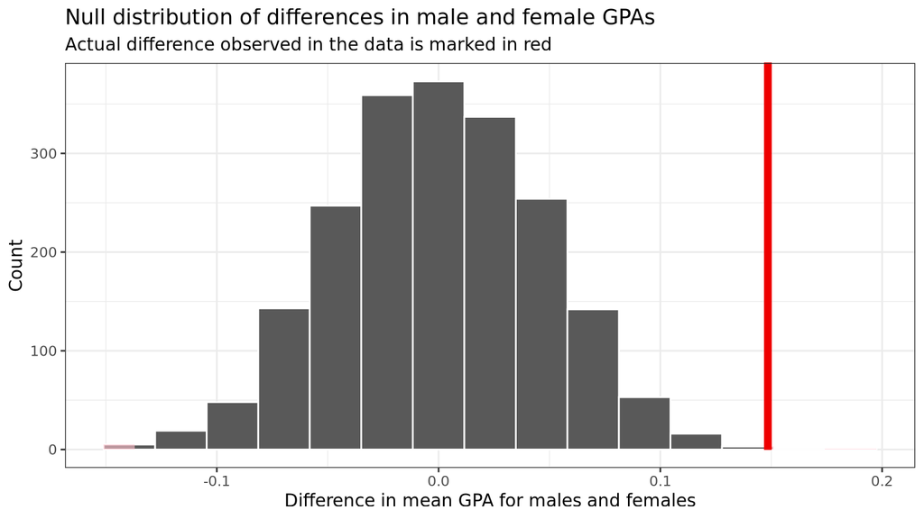

```r
gpa_diff_under_null %>%
  visualize() +
  labs(x = "Difference in mean GPA for males and females", y = "Count",
       title = "Null distribution of differences in male and female GPAs",
      subtitle = "Actual difference observed in the data is marked in red") +
  shade_p_value(obs_stat = obs_diff_gpa_sex, direction = "two-sided") +
  theme_bw()
```

**Note that zero is the center of this null distribution.** The null hypothesis is that there is no difference between males and females in GPA score. In the permutations, zero was the most common value, because all structure was removed from the data…GPA values were sorted into male and female **at random**. Values as large as ~ 0.1 and -0.1 occurred, but much less frequently, because they are just not as likely when structure is removed from the data.

### Step 5: Calculate a p-value

```r
gpa_diff_under_null %>%
  get_pvalue(obs_stat = obs_diff_gpa_sex, direction = "both") %>%   pull() -> pvalue
pvalue
```

```
[1] 0.001
```

This result indicates that there is a 0.001 chance (very low) that we would see a difference of 0.1485209 in GPA scores between males and females (or a bigger difference) if in fact there was truly no difference between the sexes in GPA scores at the population level.

### Step 6: Calculate a Confidence Interval for the Difference

The following will allow us to calculate a 95% bootstrap percentile confidence interval for the difference between mean GPA scores for females and males.

```r
ci_diff_gpa_means <- sat_gpa %>%
  specify(gpa_fy ~ sex) %>%
  generate(reps = 2000) %>%
  calculate(stat = "diff in means", order = c("Female", "Male")) %>%
  get_ci(level = 0.95, type = "percentile")
ci_diff_gpa_means
```

| lower_ci | upper_ci |
| --- | --- |
| 0.0607254 | 0.2443354 |

## Complete all the Above Tasks with a t-test

Note that all the above steps can be done with one line of code **if a slew of assumptions** like normality and equal variance of the groups are met.

```r
t.test(gpa_fy ~ sex, var.equal = TRUE, data = sat_gpa)
```

```
    Two Sample t-test

data:  gpa_fy by sex
t = 3.1828, df = 998, p-value = 0.001504
alternative hypothesis: true difference in means between group Female and group Male is not equal to 0
95 percent confidence interval:
 0.05695029 0.24009148
sample estimates:
mean in group Female   mean in group Male
            2.544587             2.396066
```